# Differential Expression Analysis: RNA-seq with `limma-voom`

ALSF CCDL - Jaclyn Taroni

## Background

This notebook takes RNA-seq data and metadata from refine.bio and identifies differentially expressed genes. We recommend skipping quantile normalization for RNA-seq data if you want to perform differential expression analysis. (You can read more about that here in our documentation.) Here we’re using the the [*“bias corrected without an offset”* approach](https://bioconductor.org/packages/release/bioc/vignettes/tximport/inst/doc/tximport.html#use-with-downstream-bioconductor-dge-packages) described in the [tximport vignette](https://bioconductor.org/packages/release/bioc/vignettes/tximport/inst/doc/tximport.html) with limma-voom. The voom methodology was introduced in [Law et al. *Genome Biology.* 2014.](https://doi.org/10.1186/gb-2014-15-2-r29)

You may also find [this limma-voom tutorial](https://ucdavis-bioinformatics-training.github.io/2018-June-RNA-Seq-Workshop/thursday/DE.html) from the [UC Davis Bioinformatics Core 2018 RNA-Seq Workshop](https://ucdavis-bioinformatics-training.github.io/2018-June-RNA-Seq-Workshop/) helpful.

Note that we perform a simple two-group comparison here. Consult the [limma user guide](https://bioconductor.org/packages/release/bioc/vignettes/limma/inst/doc/usersguide.pdf) for more information about additional experimental designs.

### Dataset

We are using [`SRP078441`](https://www.refine.bio/experiments/SRP078441/rna-seq-of-primary-patient-aml-samples) from [Micol et al. *Nat Commun.* 2017.](https://dx.doi.org/10.1038/ncomms15429) in this notebook.

The authors performed RNA-seq on primary peripheral blood and bone marrow samples from patients with acute myeloid leukemia. We will compare samples from patients without *ASXL1/2* mutations to samples from patients with *ASXL1/2* without taking tissue of origin into account.

## Set up

Install `limma` and `edgeR` if not yet installed.

```r
if (!("limma" %in% installed.packages())) {
  # Install limma
  BiocManager::install("limma", update = FALSE)
}

if (!("edgeR" %in% installed.packages())) {
  # Install limma
  BiocManager::install("edgeR", update = FALSE)
}
```

Load libraries.

```r
# Magrittr pipe
`%>%` <- dplyr::`%>%`

# Attach libraries
library(limma)
library(edgeR)
```

Create output folders.

```r
# Define the file path to the results directory
results_dir <- "results" # Replace with path to desired output results directory

# Create the results folder if it doesn't exist
if (!dir.exists(results_dir)) {
  dir.create(results_dir)
}

# Define the file path to the results directory
plots_dir <- "plots" # Replace with path to desired output plots directory

# Create the plots folder if it doesn't exist
if (!dir.exists(plots_dir)) {
  dir.create(plots_dir)
}
```

### Read in refine.bio data

```r
# Read in metadata tsv file
metadata.df <- readr::read_tsv(file.path("data", # Replace with path to your metadata file
                                         "metadata_SRP078441.tsv" # Replace with the name of your metadata file
                                         )) %>%
  # Get rid of columns that have only NAs
  dplyr::select(-which(apply(is.na(.), 2, all)))
# Read in data tsv file
expression.df <- readr::read_tsv(file.path("data", # Replace with path to your data file
                                           "SRP078441.tsv" # Replace with the name of your data file
                                           )) %>%
  tibble::column_to_rownames("Gene") # Store gene names as the rownames for now
```

The information we need to make the comparison is in the `refinebio_title` column of the metadata data.frame.

```r
head(metadata.df$refinebio_title)
```

```
[1] "CBF77-Blood-ASXL2"  "CBF124-BM-ASXLwt"   "CBF234-BM-ASXLwt"
[4] "CBF370-BM-ASXL2"    "CBF369-Blood-ASXL2" "CBF54-BM-ASXLwt"
```

We’ll use some tidyverse functionality to extract this information into its own column to make it easier to use.

```r
metadata.df <- metadata.df %>%
  # the last bit of the title, separated by "-" contains the mutation
  # information that we want to extract
  dplyr::mutate(mutation_status = stringr::word(refinebio_title,
                                                -1, sep = "-")) %>%
  # now let's make this simpler
  dplyr::mutate(mutation_status = dplyr::case_when(
    grepl("ASXL1|ASXL2", mutation_status) ~ "mutation",
    grepl("ASXLwt", mutation_status) ~ "wildtype"
  ))
```

Let’s take a look at `metadata.df` to see if this worked.

```r
# looking at the first 6 rows of the metadata_df and only at the columns that
# contain the title and the mutation status we extracted from the title
head(dplyr::select(metadata.df, refinebio_title, mutation_status))
```

| refinebio_title | mutation_status |
| --- | --- |
| CBF77-Blood-ASXL2 | mutation |
| CBF124-BM-ASXLwt | wildtype |
| CBF234-BM-ASXLwt | wildtype |
| CBF370-BM-ASXL2 | mutation |
| CBF369-Blood-ASXL2 | mutation |
| CBF54-BM-ASXLwt | wildtype |

## Differential expression analysis

Now that we’ve prepped our data, we’re ready to test for differentially expressed genes.

Let’s check if samples are in the same order.

```r
all.equal(colnames(expression.df), metadata.df$refinebio_accession_code)
```

```
[1] "12 string mismatches"
```

```r
# put samples in ascending order according to their accession code in the
# metadata
metadata.df <- metadata.df %>%
  dplyr::arrange(refinebio_accession_code)

# use the metadata.df information to reorder the columns of the expression
# data frame
expression.df <- expression.df[, metadata.df$refinebio_accession_code]
```

Check again.

```r
all.equal(colnames(expression.df), metadata.df$refinebio_accession_code)
```

```
[1] TRUE
```

### limma-voom

Here, we’re following the steps in [this section](https://bioconductor.org/packages/release/bioc/vignettes/tximport/inst/doc/tximport.html#limma-voom) of the [tximport vignette](https://bioconductor.org/packages/release/bioc/vignettes/tximport/inst/doc/tximport.html).

To use `edgeR` functionality such as filtering and calculating normalization factors, we will construct a [`DGEList`](https://www.rdocumentation.org/packages/edgeR/versions/3.10.5/topics/DGEList-class) using the refine.bio data as the `counts`.

```r
dge.list <- DGEList(as.matrix(expression.df))
```

`DGEList` is a particular type of [S4 class](http://adv-r.had.co.nz/S4.html).

```r
str(dge.list)
```

```
Formal class 'DGEList' [package "edgeR"] with 1 slot
  ..@ .Data:List of 2
  .. ..$ : num [1:43363, 1:16] 52.735 0.616 664.907 869.615 965.165 ...
  .. .. ..- attr(*, "dimnames")=List of 2
  .. .. .. ..$ : chr [1:43363] "ENSG00000000003" "ENSG00000000005" "ENSG00000000419" "ENSG00000000457" ...
  .. .. .. ..$ : chr [1:16] "SRR3895734" "SRR3895735" "SRR3895736" "SRR3895737" ...
  .. ..$ :'data.frame': 16 obs. of  3 variables:
  .. .. ..$ group       : Factor w/ 1 level "1": 1 1 1 1 1 1 1 1 1 1 ...
  .. .. ..$ lib.size    : num [1:16] 31372470 27699067 31871954 28935062 32943298 ...
  .. .. ..$ norm.factors: num [1:16] 1 1 1 1 1 1 1 1 1 1 ...
```

Filter to only retain genes with enough counts for statistical analysis.

```r
keep <- filterByExpr(dge.list)
dge.list <- dge.list[keep, ]
```

If we check the structure again, we can see many fewer genes are retained.

```r
str(dge.list)
```

```
Formal class 'DGEList' [package "edgeR"] with 1 slot
  ..@ .Data:List of 2
  .. ..$ : num [1:14557, 1:16] 52.7 664.9 869.6 965.2 2598.8 ...
  .. .. ..- attr(*, "dimnames")=List of 2
  .. .. .. ..$ : chr [1:14557] "ENSG00000000003" "ENSG00000000419" "ENSG00000000457" "ENSG00000000460" ...
  .. .. .. ..$ : chr [1:16] "SRR3895734" "SRR3895735" "SRR3895736" "SRR3895737" ...
  .. ..$ :'data.frame': 16 obs. of  3 variables:
  .. .. ..$ group       : Factor w/ 1 level "1": 1 1 1 1 1 1 1 1 1 1 ...
  .. .. ..$ lib.size    : num [1:16] 31372470 27699067 31871954 28935062 32943298 ...
  .. .. ..$ norm.factors: num [1:16] 1 1 1 1 1 1 1 1 1 1 ...
```

The next step is to calculate normalization factors for scaling the raw library sizes.

```r
dge.list <- calcNormFactors(dge.list)
```

If we take another look at the structure of `dge.list`, we can see that the `norm.factors` element has changed as a result of running `calcNormFactors`.

```r
str(dge.list)
```

```
Formal class 'DGEList' [package "edgeR"] with 1 slot
  ..@ .Data:List of 2
  .. ..$ : num [1:14557, 1:16] 52.7 664.9 869.6 965.2 2598.8 ...
  .. .. ..- attr(*, "dimnames")=List of 2
  .. .. .. ..$ : chr [1:14557] "ENSG00000000003" "ENSG00000000419" "ENSG00000000457" "ENSG00000000460" ...
  .. .. .. ..$ : chr [1:16] "SRR3895734" "SRR3895735" "SRR3895736" "SRR3895737" ...
  .. ..$ :'data.frame': 16 obs. of  3 variables:
  .. .. ..$ group       : Factor w/ 1 level "1": 1 1 1 1 1 1 1 1 1 1 ...
  .. .. ..$ lib.size    : num [1:16] 31372470 27699067 31871954 28935062 32943298 ...
  .. .. ..$ norm.factors: num [1:16] 1.638 0.912 1.396 0.876 1.515 ...
```

`limma` requires us to specify a design matrix that captures the mutated vs. wildtype comparison.

```r
design <- model.matrix(~ metadata.df$mutation_status)
```

This is the voom step that transforms data to log2CPM, estimates the mean-variance relationship and computes observation-level weights.

```r
voom.elist <- voom(dge.list, design)  # ready for lmFit
```

`voom()` returns an `EList`.

```r
str(voom.elist)
```

```
Formal class 'EList' [package "limma"] with 1 slot
  ..@ .Data:List of 4
  .. ..$ :'data.frame': 16 obs. of  3 variables:
  .. .. ..$ group       : Factor w/ 1 level "1": 1 1 1 1 1 1 1 1 1 1 ...
  .. .. ..$ lib.size    : num [1:16] 51374728 25272452 44479246 25340326 49919032 ...
  .. .. ..$ norm.factors: num [1:16] 1.638 0.912 1.396 0.876 1.515 ...
  .. ..$ : num [1:14557, 1:16] 0.0513 3.6951 4.0821 4.2324 5.6609 ...
  .. .. ..- attr(*, "dimnames")=List of 2
  .. .. .. ..$ : chr [1:14557] "ENSG00000000003" "ENSG00000000419" "ENSG00000000457" "ENSG00000000460" ...
  .. .. .. ..$ : chr [1:16] "SRR3895734" "SRR3895735" "SRR3895736" "SRR3895737" ...
  .. ..$ : num [1:14557, 1:16] 1.58 2.34 2.35 2.35 2.29 ...
  .. ..$ : num [1:16, 1:2] 1 1 1 1 1 1 1 1 1 1 ...
  .. .. ..- attr(*, "dimnames")=List of 2
  .. .. .. ..$ : chr [1:16] "1" "2" "3" "4" ...
  .. .. .. ..$ : chr [1:2] "(Intercept)" "metadata.df$mutation_statuswildtype"
  .. .. ..- attr(*, "assign")= int [1:2] 0 1
  .. .. ..- attr(*, "contrasts")=List of 1
  .. .. .. ..$ metadata.df$mutation_status: chr "contr.treatment"
```

Now we’re ready to fit a linear model, apply smoothing, and extract the results in tabular format.

```r
# Apply linear model to data
fit <- lmFit(voom.elist, design = design)

# Apply empirical Bayes to smooth standard errors
fit <- eBayes(fit)

# Apply multiple testing correction and obtain stats
stats <- topTable(fit, number = nrow(expression.df)) %>%
  tibble::rownames_to_column("Gene")
```

```
Removing intercept from test coefficients
```

Write the `topTable` output to file.

```r
readr::write_tsv(stats, file.path(results_dir,
                                  "SRP078441_limma_results.tsv" # Replace with a relevant output file name
                                  ))
```

### Volcano plot

```r
# Create volcano plot
voc.plot <- volcanoplot(fit, main = "Volcano Plot SRP078441") # Replace title with one relevant to your data

# Save plot to png
png(file.path(plots_dir,
              "volcano_plot_SRP078441.png" # Replace with a plot name relevant to your data
              ))
```

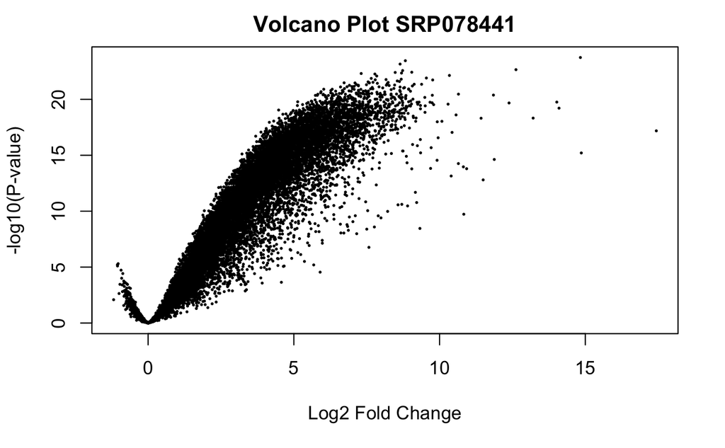

```r
volcanoplot(fit, main = "Volcano Plot SRP078441") # Replace title with one relevant to your data
dev.off()
```